# Example Rmarkdown document: estimating π

Stephen J Eglen

## 0.1 Disclaimer

Not everything is yet working (October 2022) in this document, compared to the Rnw version. Compared to LaTeX, I think there is less flexibility for writing papers/reports, but for simple documents, the Rmd approach may be quicker to write and sufficient for your needs. Bookdown is a system for writing books, but can also be used for writing reports, as is done here.

# 1 Introduction

This is an example document created using the rmarkdown/bookdown system https://bookdown.org/. Rmarkdown is a tool for combining both documentation and R code within the same file, similar to Sweave. For this document, the master file is `estimatek.Rmd`. This is processed by rmarkdown in R, which runs the R code to generate textual/graphical output, and also creates a HTML document. On recent machines, once rmarkdown and kntir are installed, you should be able to generate the pdf using:

```r
require(rmarkdown)
render('estimatek.Rnw')
```

Within RStudio, there is a handy “Knit HTML” button.

Both estimatek.Rmd and estimatek.html are available from: https://github.com/lgatto/spr/tree/master/estimate (you will need `estimatek.Rmd` and `diff.R`)

Knitr and rmarkdown have built in support for caching. By default it is turned off in this document, but change FALSE to TRUE in the following code-chunk and see if you can work out what happens:

```r
require(xtable)
require(printr)
require(knitr) ## for kable
knitr::opts_chunk$set(cache=FALSE)
```

# 2 Task: estimate the value of $\pi$

Our task is to estimate the value of $\pi$ by simulating darts being thrown at a dartboard. Imagine that the person throwing the darts is not very good, and randomly throws each dart so that it falls uniformly within a square of side length $2r$, with the dartboard of radius $r$ centred within that square. If the player throws $n$ darts, and $d$ of them hit the dartboard, then for large enough $n$, the ratio $d/n$ should approximate the ratio of the area of the dartboard to the enclosing square, $\pi r^2 / 4 r^2 \equiv \pi/4$. From this, we can estimate $\pi \approx 4d/n$.

We start with an example, see Figure 2.1, using R to draw both the dartboard and the surrounding square, together with `n=50` darts. The radius of the dartboard here is 1 unit, although the value is not important.

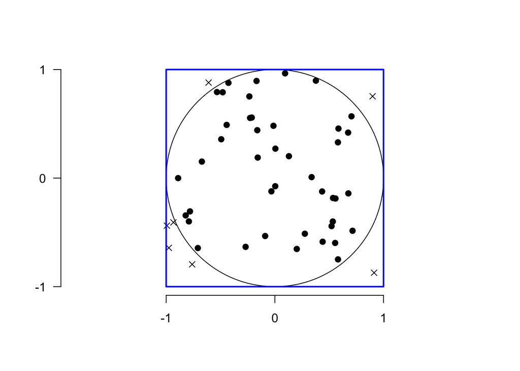

Figure 2.1: The dartboard method for estimating PI.

```r
r <- 1
n <- 50
par(las=1)
plot(NA, xlim=c(-r,r), ylim=c(-r,r), asp=1, bty='n',
     xaxt='n', yaxt='n', xlab='', ylab='')
axis(1, at=c(-r,0,r)); axis(2, at=c(-r,0,r))
symbols(x=0, y=0, circles=r, inch=F, add=T)
x <- runif(n, -r, r);  y <- runif(n, -r, r)
inside <- (x^2 + y^2) < r^2
d <- sum(inside)
points(x, y, pch=ifelse(inside, 19, 4))
rect(-r, -r, r, r, border='blue', lwd=2)
```

A dart is drawn as a filled circle if it falls within the dartboard, else it is drawn as a cross. In this case the number of darts within the circle is 43, and so the estimated value is $\pi \approx 3.44$.

The estimate of $\pi$ should improve as we increase the number of darts thrown at the dartboard. To verify this, we write a short function that, given the number of darts to throw, $n$, returns an estimate of $\pi$.

```r
estimate.pi <- function(n=1000) {
  ## Return an estimate of PI using dartboard
  ## method with N trials.
  r <- 1 ## radius of dartboard
  x <- runif(n, min=-r, max=r)
  y <- runif(n, min=-r, max=r)
  l <- sqrt(x^2 + y^2)
  d <- sum(l<r)
  4*d/n
}
```

We can then test the procedure a few times, using the default number of darts, 1000:

```r
replicate(9, estimate.pi())
```

```
## [1] 3.044 3.156 3.136 3.112 3.108 3.200 3.148 3.128 3.228
```

Finally, for a given value of $n$, we can show 99 estimates of $\pi$, as clearly the estimate will vary from run to run. In Figure 2.2, we compare the estimates of $\pi$ for three different values of $n$.

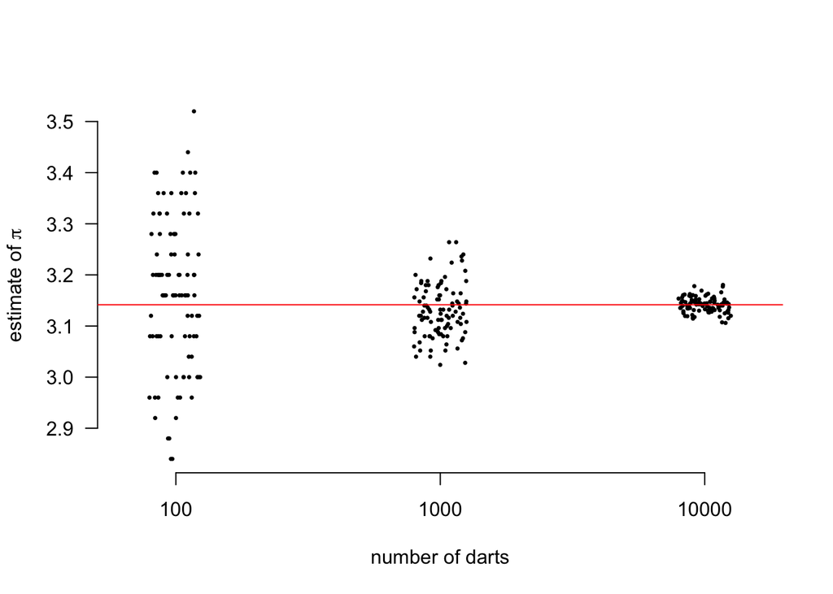

Figure 2.2: Estimates of Pi as we increase number of darts

```r
ns <- 10^c(2,3,4)
res <- lapply(ns, function(n) replicate(99, estimate.pi(n)))
par(las=1, bty='n')
stripchart(res, method="jitter", group.names=ns,
           xlab="number of darts",
           ylab=expression(paste('estimate of ', pi)),
           vert=TRUE, pch=20, cex=0.5)
abline(h=pi, col='red')
```

# 3 printr

The printr package provides a convenient interface for making tables. Here’s a simple example.

```r
df = data.frame(name=c("joe", "ann", "bob"),
  age=c(19, 24, 27),
  height=c(1.8, 1.75, 1.7))
df
```

| name | age | height |
| --- | --- | --- |
| joe | 19 | 1.80 |
| ann | 24 | 1.75 |
| bob | 27 | 1.70 |

Or you can add a caption, see Table 3.1 below.

```r
kable(df, caption="Example output from kable")
```

Table 3.1: Example output from kable

| name | age | height |
| --- | --- | --- |
| joe | 19 | 1.80 |
| ann | 24 | 1.75 |
| bob | 27 | 1.70 |

# 4 Listing

Finally, an example listing. We read in all the code from a given file (here diff.R) and then assign it to the ``all’’ label which we then include without evaluation, or showing it. We then can show the code in the Appendix of this document. You could use this as a way of putting your code in an appendix, but using it in the main part of the document.

```r
x <- c(5.9, 10.2, 12.4, 18.8)
all.equal(diff1(x), diff2(x))
```

```
## [1] TRUE
```

See http://yihui.name/knitr/demo/externalization/ for further information.

# 5 References

References can be included from your bib file: (R Core Team 2016) (Xie 2016).

## 5.1 Compiling this document

```r
rmarkdown::render('estimatek.Rmd')
```

# 6 Appendix

```r
diff1 <- function(e) {
  ## Explicit loop
  n <- length(e)
  interval <- rep(0, n-1) ## pre-allocate result
  for (i in 1:(n-1)) {
    interval[i] <- e[i+1] - e[i]
  }
  interval
}

diff2 <- function(e) {
  ## Vectorized solution
  n <- length(e)
  e[-1] - e[-n]
}

x <- c(5.9, 10.2, 12.4, 18.8)
all.equal(diff1(x), diff2(x))
```

# References

R Core Team. 2016. *R: A Language and Environment for Statistical Computing*. Vienna, Austria: R Foundation for Statistical Computing. https://www.R-project.org/.

Xie, Yihui. 2016. *Bookdown: Authoring Books and Technical Documents with R Markdown*. 1st ed. CRC Press, Taylor & Francis Group.